# MS1Match Tutorial

Ruibing Shi

3 March 2026

## 1 Load Required Packages

First, load all required packages:

```r
library(MS1Match)
library(xcms)
library(Spectra)
library(BiocParallel)
library(tibble)
library(dplyr)
library(tidyr)
```

## 2 Overview

This vignette demonstrates the MS1Match workflow using the `StM14` demo dataset. The workflow includes direct matching of detected features to MS1 and MS2 libraries, followed by feature-level ion annotation using adduct and neutral loss reference tables, and direct target list matching.

The workflow consists of the following main steps:

1. Raw data processing and feature table import
2. Library parsing
3. Library-guided feature grouping and annotation
4. Feature-level ion annotation
5. Direct target list matching

## 3 Data Import and Peak Detection

### 3.1 Load Demo Dataset

We begin by loading the preprocessed LC–MS demo dataset `StM14`from **xcms**, included in the `MS1Match` package.

```r
result_StM14 <- readRDS(
  system.file("extdata", "result_StM14.rds", package = "MS1Match")
)
```

The object `result_StM14` is a list containing four elements:

- `result_StM14[[1]]`: an `XCMSnExp` objectfrom **xcms**
- `result_StM14[[2]]`: feature definition table
- `result_StM14[[3]]`: feature intensity table
- `result_StM14[[4]]`: an `XChromatograms` object storing extracted ion chromatograms (EICs)

### 3.2 Prepare the Feature Table

We now create a feature table by combining the output from `result_StM14[[2]]` (feature definitions) and `result_StM14[[3]]` (intensity values). The table is then cleaned and prepared for downstream annotation.

In particular:

```r
result_StM14_FT_filtered <- processFeatureTable(result_StM14, sample_cols = "mzxml", sort_by ="rtmed")
```

check the feature table:

```r
head(result_StM14_FT_filtered)
```

```
#>   feature_name    mzmed    mzmin    mzmax     rtmed     rtmin     rtmax npeaks PA14_Si11_10uM PA14_Si11_4uM PA14_Si11_8uM ms_level Pool-10um Si11 MS_GA2_01_50172.mzXML
#> 1       FT2880 644.0106 644.0105 644.0106  6.791085  6.774170  6.946204      3              3             0             0        1                            66762.904
#> 2       FT0547 175.0366 175.0366 175.0366  8.898557  8.873719  9.151436      3              3             0             0        1                            27539.042
#> 3       FT0245 131.1180 131.1180 131.1180 10.305093 10.044186 10.380240      3              3             0             0        1                            58334.126
#> 4       FT0757 220.0394 220.0393 220.0395 10.817512 10.757382 10.877642      2              2             0             0        1                             3130.450
#> 5       FT0122 114.0914 114.0914 114.0914 11.021733 10.994367 11.622209      3              3             0             0        1                            39193.492
#> 6       FT0559 177.0340 177.0340 177.0340 11.021733 10.757382 11.373832      3              3             0             0        1                             2645.578
#>   Pool-10um Si11 MS_GA2_01_50173.mzXML Pool-10um Si11 MS_GA2_01_50174.mzXML Pool-4umSi11_neu MS_GA3_01_50025.mzXML Pool-4umSi11_neu MS_GA3_01_50026.mzXML
#> 1                            60143.799                            61388.342                                     NA                                     NA
#> 2                            28070.277                            31902.982                                     NA                               1152.896
#> 3                            50269.361                            53581.440                               2782.103                               4708.095
#> 4                             2156.473                             3556.669                                     NA                                     NA
#> 5                            41591.815                            40680.384                                     NA                                     NA
#> 6                             2804.204                             3270.083                                     NA                                     NA
#>   Pool-4umSi11_neu MS_GA3_01_50027.mzXML Pool-8umSi11_neu MS_GA4_01_50029.mzXML Pool-8umSi11_neu MS_GA4_01_50030.mzXML Pool-8umSi11_neu MS_GA4_01_50031.mzXML intensity_mean
#> 1                                     NA                                     NA                                     NA                                     NA      62765.015
#> 2                               2400.280                               5051.037                               8051.482                              13017.784      14648.223
#> 3                               5034.008                               4131.739                               4513.222                               3697.936      20783.559
#> 4                                     NA                                     NA                                     NA                                     NA       2947.864
#> 5                                     NA                                     NA                                     NA                                     NA      40488.564
#> 6                                     NA                                     NA                                     NA                                     NA       2906.621
```

### 3.3 Run XCMS on Custom Files

Users can run `runXCMS()` to process their own `mzXML` or `mzML` files by specifying appropriate parameters from `xcms`.

```r
runXCMS_result <- runXCMS(files_dir,
                    peakwidth,
                    ppm,
                    snthresh,
                    mzdiff,
                    prefilter,
                    noise,
                    bw,
                    sample_name,
                    sample_group,
                    minFraction)
```

## 4 Import Mass Spectral Libraries

### 4.1 Import MS1 Spectral Library

To perform direct MS1 library matching, we import the in-house spectral library `Si14.library`, which contains MS1 spectra for 14 pure reference compounds.

```r
Si14_library <- parse_library(
  file_path = system.file(
    "extdata",
    "StM14_library",
    "Si14.library",
    package = "MS1Match"
  ),
  ionPolarity = "pos",
  spectrum_type = "MS1"
)
```

```
#> [In-house parser] Total compounds parsed: 14
#> [In-house parser] Duplicates removed: 0
#> [In-house parser] Unique compounds retained: 14
```

### 4.2 Import MS2 Spectral Library

Similarly, we import the corresponding MS2 library by specifying `spectrum_type = "MS2"`:

```r
StM14_MS2_library <- parse_library(
  file_path = system.file(
    "extdata",
    "StM14_library",
    "Si14_library_MS2.library",
    package = "MS1Match"
  ),
  ionPolarity = "pos",
  spectrum_type = "MS2"
)
```

```
#> [In-house parser] Total compounds parsed: 30
#> [In-house parser] Duplicates removed: 1
#> [In-house parser] Unique compounds retained: 14
```

## 5 MS1 library-guided feature grouping and annotation

### 5.1 MS1 Library Matching

Detected features are matched to an MS1 reference library by comparing feature *m/z* values to library primary ions (e.g., `[M+H]+`). If a primary ion match is found within tolerance, additional library peaks of the same compound are matched to neighboring features under a retention time (RT) constraint.

### 5.2 Creating a `DirectLibMatch` Object (MS1)

The constructor function `createDirectLibMatch()` generates a `DirectLibMatch` object that stores the feature table, the reference library, and all parameters required for matching.

```r
DirectLibMatch_MS1_obj <- createDirectLibMatch(
  FT = result_StM14_FT_filtered,
  compounds_list = Si14_library,
  diff_mz_thr = 0.01,
  diff_rt_thr = 20,
  ppm = 10,
  ms_level = "MS1",
  polarity = "pos"
)
```

### 5.3 Running MS1 Library Matching

The matching procedure is executed using `libAnnotate()`.

```r
direct_match_StM14_MS1_obj <- libAnnotate(
  DirectLibMatch_MS1_obj,
  compute_cosine = TRUE,
  ppm = 20,
  BPPARAM = SerialParam()
)
```

### 5.4 Accessing MS1 Matching Results

```r
direct_match_StM14_res_MS1 <- results(direct_match_StM14_MS1_obj)
```

### 5.5 Convert MS1 Results to Data Frame

```r
direct_match_StM14_res_MS1_df <- results_df(
  direct_match_StM14_MS1_obj,
  collapse_full = TRUE,
  remove_full = TRUE,
  suffix = "_merge"
)
```

```r
head(direct_match_StM14_res_MS1_df)
```

### 5.6 Visualizing MS1 Matches Output

`MS1Match` provides visualization tools to help inspect the quality of spectral matches between query features and reference library compounds using mirror. This function `plotMirrorSpectraSingle` creates a mirror plot using the matched feature peaks (on top) and reference library spectrum (on bottom). The cosine similarity score (inner and outer cosine from `Spectra`) and the match score are displayed in the plot. If no `output_dir` is provided, only the plot is shown. If `output_dir` is set, the plot will be saved as a PNG file instead.

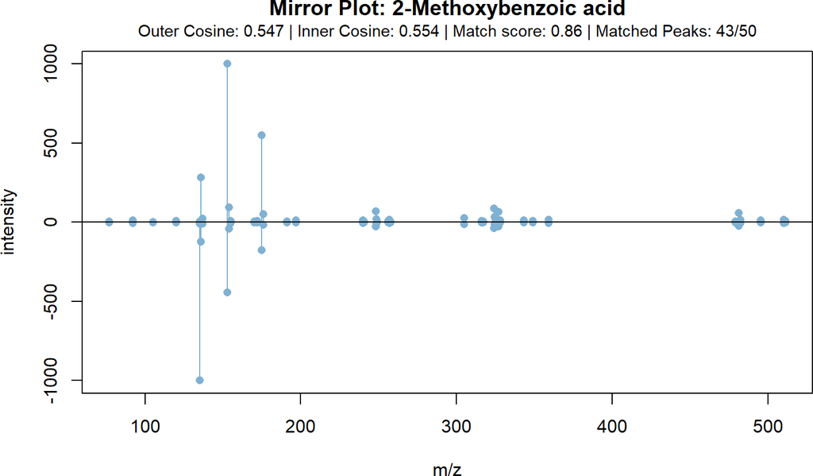

```r
plotMirrorSpectraSingle(object = direct_match_StM14_MS1_obj, match = direct_match_StM14_res_MS1[[1]], output_dir = NULL)
```

### 5.7 Plot All Matches and Export

To generate and export mirror plots for all matched compounds at once:

```r
plotMirrorSpectra(object = direct_match_StM14_MS1_obj, matches = direct_match_StM14_res_MS1, output_dir = "mirror_plots_StM14_res_MS1")
```

### 5.8 MS2 library-guided feature grouping and annotation

For MS2 matching, candidate metabolites are first linked to features via precursor *m/z* matching. After identifying the precursor-matched feature, MS2 fragment peaks are directly matched to neighboring features. Cosine similarity scores may be computed but are not used as filtering criteria in this workflow.

### 5.9 Creating a `DirectLibMatch` Object (MS2)

```r
DirectLibMatch_MS2_obj <- createDirectLibMatch(
  FT = result_StM14_FT_filtered,
  compounds_list = StM14_MS2_library,
  diff_mz_thr = 0.01,
  diff_rt_thr = 20,
  ppm = 10,
  ms_level = "MS2",
  polarity = "pos"
)
```

### 5.10 Running MS2 Library Matching

```r
direct_match_StM14_MS2_obj <- libAnnotate(
  DirectLibMatch_MS2_obj,
  compute_cosine = TRUE,
  BPPARAM = SerialParam()
)
```

### 5.11 Accessing MS2 Matching Results

```r
direct_match_StM14_res_MS2 <- results(direct_match_StM14_MS2_obj)
```

### 5.12 Convert MS2 Results to Data Frame

```r
direct_match_StM14_res_MS2_df <- results_df(
  direct_match_StM14_MS2_obj,
  collapse_full = TRUE,
  remove_full = TRUE,
  suffix = "_merge"
)
```

```r
head(direct_match_StM14_res_MS2_df)
```

### 5.13 Visualizing MS2 Spectral Matches

Similarly, we plot the spectral mirror plot for the MS2 library matching result:

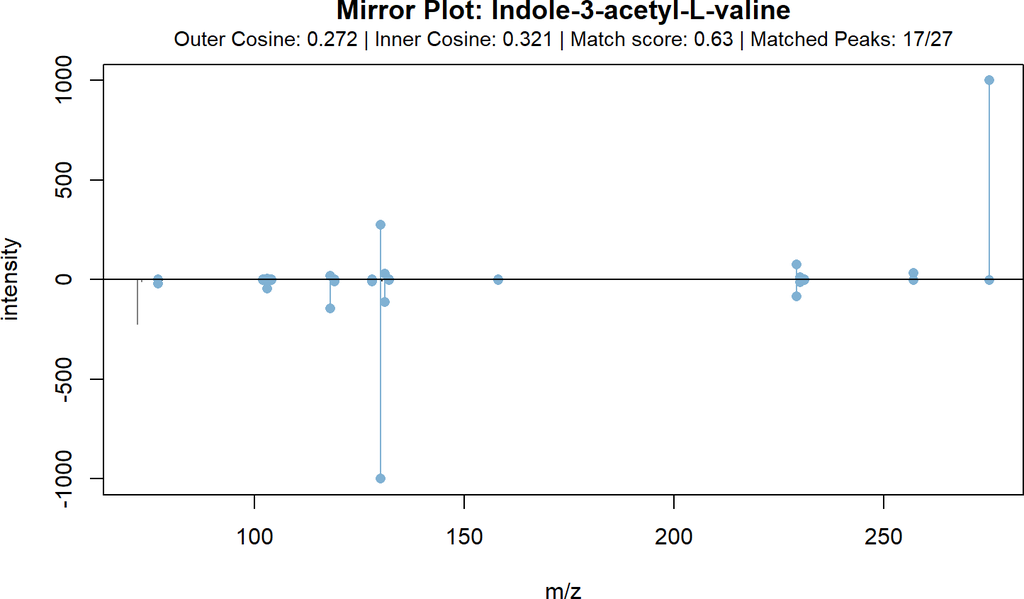

```r
plotMirrorSpectraSingle(object = DirectLibMatch_MS2_obj, match = direct_match_StM14_res_MS2[[5]])
```

And export for all matched compound:

```r
plotMirrorSpectra(object = DirectLibMatch_MS2_obj, matches = direct_match_StM14_res_MS2, output_dir = "mirror_plots_StM14_res_MS2")
```

### 5.14 Compare MS1 and MS2 library matching results

To evaluate the annotation performance, we compare the number of features directly matched using the MS1 library versus the MS2 library.

```r
direct_match_res_MS1_df_subset <- direct_match_StM14_res_MS1_df[,c("Compound_name", "Matched_peaks","Total_library_peaks")] %>% distinct()

direct_match_res_MS2_df_subset <- direct_match_StM14_res_MS2_df[,c("Compound_name", "Matched_peaks","Total_library_peaks")] %>% distinct()



direct_match_res_MS1_MS2_join <- full_join(direct_match_res_MS1_df_subset, direct_match_res_MS2_df_subset, by = c("Compound_name"),
                                           suffix = c("_MS1", "_MS2"))
```

The result:

```
#>               Compound_name Matched_peaks_MS1 Total_library_peaks_MS1 Matched_peaks_MS2 Total_library_peaks_MS2
#> 1     2-Methoxybenzoic acid                43                      50                11                      30
#> 2      3-Indoleacetonitrile                28                      80                 7                      12
#> 3               Biochanin A                19                      50                 3                      48
#> 4  Indole-3-acetyl-L-valine                68                      73                17                      27
#> 5   Indole-3-carboxaldehyde                31                      34                10                      19
#> 6                   Kinetin                 5                      10                 3                       6
#> 7                  Naproxen               120                     124                20                      42
#> 8              Nortriptylin                28                      36                47                     105
#> 9                Novobiocin                45                     122                 4                    9087
#> 10                Phlorizin                52                      56                17                      53
#> 11                    Rutin                48                     123                 3                      16
#> 12       Trans-Ferulic acid                77                      84                25                      55
#> 13              Trimetoprim                 6                       6                 8                     146
#> 14          p-Coumaric acid                67                      99                10                      28
```

## 6 Feature-Level Ion Annotation

### 6.1 Import Supporting Tables

```r
adduct_table <- read.csv(
  system.file("extdata", "Adducts", "adducts.csv", package = "MS1Match")
)

neutral_loss_table <- read.csv(
  system.file("extdata", "Neutral loss", "neutral loss database.csv", package = "MS1Match"),
  check.names = TRUE
)
```

### 6.2 Feature Annotation Based on MS1 Matching

Using the MS1 matching results (`direct_match_StM14_res_MS1`), we assign ion species such as primary ions, adducts, neutral losses, and isotopes.

```r
PeakAnnotation_obj_MS1 <- createPeakAnnotationFromLibraryMatch(
  library_matches = direct_match_StM14_res_MS1,
  adducts_df = adduct_table,
  neutral_loss_table = neutral_loss_table,
  polarity = "positive"
)

StM14_annotate_res_ms1 <- annotate(PeakAnnotation_obj_MS1)
```

```r
annotate_peaks_StM14_result_df_ms1 <- annotations_df(StM14_annotate_res_ms1)
```

```r
head(annotate_peaks_StM14_result_df_ms1)
```

```
#>   feature_name        mz       rt intensity         Compound_name   Lib_group Ion_type Compound_M PI_match          adduct_match
#> 1       FT0002  77.03869 507.4337 17468.611 2-Methoxybenzoic acid Lib_group_1      M+H   152.0473
#> 2       FT0033  92.02568 507.4337 38701.196 2-Methoxybenzoic acid Lib_group_1      M+H   152.0473
#> 3       FT0086 105.03353 507.4877  9151.372 2-Methoxybenzoic acid Lib_group_1      M+H   152.0473
#> 4       FT0159 120.02057 507.4330 27833.912 2-Methoxybenzoic acid Lib_group_1      M+H   152.0473
#> 5       FT0271 135.04425 507.4570 15247.300 2-Methoxybenzoic acid Lib_group_1      M+H   152.0473          [M+H-H2O]+ 152.047344
#> 6       FT0285 135.33165 507.4330 16130.485 2-Methoxybenzoic acid Lib_group_1      M+H   152.0473
#>                                                                     NL_match iso_annotation Match_peak_score inner_cosine outer_cosine
#> 1 <- CO (FT0086); <- C2H2O2 (FT0271); <- CN2O5 (FT0665); <- C3H9O6P (FT0933)                            0.86    0.5537815     0.546912
#> 2                                          <- CO (FT0159); <- CH3NO (FT0293)                            0.86    0.5537815     0.546912
#> 3                                         <- CH2O (FT0271); <- CH3O (FT0287)                            0.86    0.5537815     0.546912
#> 4                       <- CH3 (FT0271); <- NH3 (FT0293); <- C4H8O4 (FT0865)                            0.86    0.5537815     0.546912
#> 5                                                            <- H2O (FT0399)                            0.86    0.5537815     0.546912
#> 6                                                                                                       0.86    0.5537815     0.546912
```

### 6.3 Feature Annotation Based on MS2 Matching

Using the MS2 matching results (`direct_match_StM14_res_MS2`), we assign ion species to the precursor- and fragment-matched features.

```r
PeakAnnotation_obj_MS2 <- createPeakAnnotationFromLibraryMatch(
  library_matches = direct_match_StM14_res_MS2,
  adducts_df = adduct_table,
  neutral_loss_table = neutral_loss_table,
  polarity = "positive"
)

StM14_annotate_res_ms2 <- annotate(PeakAnnotation_obj_MS2)
```

```r
annotate_peaks_StM14_result_df_ms2 <- annotations_df(StM14_annotate_res_ms2)
```

```r
head(annotate_peaks_StM14_result_df_ms2)
```

```
#>   feature_name        mz       rt intensity         Compound_name   Lib_group  Ion_type Compound_M PI_match            adduct_match
#> 1       FT0002  77.03869 507.4337 17468.611 2-Methoxybenzoic acid Lib_group_1 Precursor   152.0473
#> 2       FT0033  92.02568 507.4337 38701.196 2-Methoxybenzoic acid Lib_group_1 Precursor   152.0473
#> 3       FT0036  95.04915 507.4077  3355.679 2-Methoxybenzoic acid Lib_group_1 Precursor   152.0473
#> 4       FT0086 105.03353 507.4877  9151.372 2-Methoxybenzoic acid Lib_group_1 Precursor   152.0473
#> 5       FT0103 107.04914 507.4330  7795.644 2-Methoxybenzoic acid Lib_group_1 Precursor   152.0473          [M+H-CH2O2]+ 152.047344
#> 6       FT0159 120.02057 507.4330 27833.912 2-Methoxybenzoic acid Lib_group_1 Precursor   152.0473
#>                                                                NL_match iso_annotation Match_peak_score inner_cosine outer_cosine
#> 1 <- H2O (FT0036); <- CO (FT0086); <- CH2O (FT0103); <- C2H2O2 (FT0271)                       0.3666667   0.08695481   0.07605976
#> 2                    <- CH3 (FT0103); <- CO (FT0159); <- CH3NO (FT0293)                       0.3666667   0.08695481   0.07605976
#> 3                                                    <- C2H2O2 (FT0399)                       0.3666667   0.08695481   0.07605976
#> 4                                    <- CH2O (FT0271); <- CH3O (FT0287)                       0.3666667   0.08695481   0.07605976
#> 5                     <- CO (FT0271); <- NO (FT0293); <- CH2O2 (FT0399)                       0.3666667   0.08695481   0.07605976
#> 6                                      <- CH3 (FT0271); <- NH3 (FT0293)                       0.3666667   0.08695481   0.07605976
```

## 7 Direct Target List Matching

In this section, we perform direct matching between feature table `m/z` values and target lists using known compounds from curated databases.

### 7.1 Import Target Lists

We first import the **PAMDB** target list for *Pseudomonas aeruginosa* metabolites:

```r
PA14_target_list <- PAMD_target_list_import(target_list_path = system.file("extdata", "Pseudomonas_target_list", "PaMetV2.csv", package = "MS1Match"))
```

```r
head(PA14_target_list)
```

```
#>                                 Name     Formula RT MainPositiveAdduct MainNegativeAdduct
#> C4H6O3            2-Ketobutyric acid      C4H6O3  0             [M+H]+             [M-H]-
#> C9H12N2O5               Deoxyuridine   C9H12N2O5  0             [M+H]+             [M-H]-
#> C9H13N3O4              Deoxycytidine   C9H13N3O4  0             [M+H]+             [M-H]-
#> C5H8O3         a-Ketoisovaleric acid      C5H8O3  0             [M+H]+             [M-H]-
#> C4H8O3      3-Hydroxyisobutyric acid      C4H8O3  0             [M+H]+             [M-H]-
#> C10H16N2O3S                   Biotin C10H16N2O3S  0             [M+H]+             [M-H]-
#>                                                                                                                             InChI exactMass   [M+H]+   [M-H]-
#> C4H6O3                                                                            InChI=1S/C4H6O3/c1-2-3(5)4(6)7/h2H2,1H3,(H,6,7)  102.0317 103.0390 101.0244
#> C9H12N2O5    InChI=1S/C9H12N2O5/c12-4-6-5(13)3-8(16-6)11-2-1-7(14)10-9(11)15/h1-2,5-6,8,12-13H,3-4H2,(H,10,14,15)/t5-,6+,8+/m0/s1  228.0746 229.0819 227.0673
#> C9H13N3O4    InChI=1S/C9H13N3O4/c10-7-1-2-12(9(15)11-7)8-3-5(14)6(4-13)16-8/h1-2,5-6,8,13-14H,3-4H2,(H2,10,11,15)/t5-,6+,8+/m0/s1  227.0906 228.0979 226.0833
#> C5H8O3                                                                         InChI=1S/C5H8O3/c1-3(2)4(6)5(7)8/h3H,1-2H3,(H,7,8)  116.0473 117.0546 115.0401
#> C4H8O3                                                                       InChI=1S/C4H8O3/c1-3(2-5)4(6)7/h3,5H,2H2,1H3,(H,6,7)  104.0473 105.0546 103.0401
#> C10H16N2O3S InChI=1S/C10H16N2O3S/c13-8(14)4-2-1-3-7-9-6(5-16-7)11-10(15)12-9/h6-7,9H,1-5H2,(H,13,14)(H2,11,12,15)/t6-,7-,9-/m0/s1  244.0882 245.0954 243.0809
```

The MS1Match package also includes a target list for human plasma metabolites (HMDB):

```r
hmdb_target_list <- HMDB_target_list_import(target_list_path = system.file("extdata", "hmdb", "hmdb_blood_detected.csv", package = "MS1Match"), IonPolarity = "pos")
```

```r
head(hmdb_target_list)
```

```
#>       HMDB_ID                  Name                                                                 SMILES                    INCHIKEY   Formula AVERAGE_MASS MONO_MASS exactMass    [M+H]+
#> 1 HMDB0000001     1-Methylhistidine                                            CN1C=NC(C[C@H](N)C(O)=O)=C1 BRMWTNUJHUMWMS-LURJTMIESA-N C7H11N3O2     169.1811  169.0851  169.0851 170.09240
#> 2 HMDB0000002    1,3-Diaminopropane                                                                  NCCCN XFNJVJPLKCPIBV-UHFFFAOYSA-N   C3H10N2      74.1249   74.0844   74.0844  75.09167
#> 3 HMDB0000005    2-Ketobutyric acid                                                          CCC(=O)C(O)=O TYEYBOSBBBHJIV-UHFFFAOYSA-N    C4H6O3     102.0886  102.0317  102.0317 103.03897
#> 4 HMDB0000008 2-Hydroxybutyric acid                     [H]OC(=O)[C@@]([H])(O[H])C([H])([H])C([H])([H])[H] AFENDNXGAFYKQO-VKHMYHEASA-N    C4H8O3     104.1050  104.0473  104.0473 105.05462
#> 5 HMDB0000010      2-Methoxyestrone [H][C@@]12CCC(=O)[C@@]1(C)CC[C@]1([H])C3=C(CC[C@@]21[H])C=C(O)C(OC)=C3 WHEUWNKSCXYKBU-QPWUGHHJSA-N  C19H24O3     300.3921  300.1725  300.1725 301.17982
#> 6 HMDB0000011 3-Hydroxybutyric acid                                                      C[C@@H](O)CC(O)=O WHBMMWSBFZVSSR-GSVOUGTGSA-N    C4H8O3     104.1045  104.0473  104.0473 105.05462
#>      [M-H]-
#> 1 168.07785
#> 2  73.07712
#> 3 101.02442
#> 4 103.04007
#> 5 299.16527
#> 6 103.04007
```

## 8 Match Features to a Target List

In addition to library-based matching, features can be directly matched to an external target list based on the *m/z* of primary ions.

Matching is performed using:

- `[M+H]+` in positive ion mode
- `[M−H]−` in negative ion mode

```r
DirectTarget_obj <- DirectTargetMatch(
  result_StM14_FT_filtered,
  PA14_target_list,
  PIon = "[M+H]+",
  diff_mz_thr = 0.005,
  ppm = 10
)

StM14_PAMDB_PI_match <- PImatch_target(DirectTarget_obj)
```

The returned object is a list containing primary ion matches.  
For easier inspection, convert the results to a data frame:

```r
StM14_PAMDB_PI_match_df <- PImatch_df(StM14_PAMDB_PI_match)

head(StM14_PAMDB_PI_match_df)
```

```
#>   Feature_name Feature_mz                  Comp_name           PI_name
#> 1       FT0547   175.0366    N-carbamoyl-L-aspartate [M+H]+ 174.027671
#> 2       FT0597   184.9854 Phosphohydroxypyruvic acid [M+H]+ 183.977289
#> 3       FT0598   184.9853 Phosphohydroxypyruvic acid [M+H]+ 183.977289
#> 4       FT0107   110.0087           Ethylphosphonate [M+H]+ 109.005456
#> 5       FT0421   156.0767                L-Histidine [M+H]+ 155.069477
#> 6       FT0645   192.0243     2,5-Diketo-D-gluconate [M+H]+ 191.019178
```

## 9 Join Annotation Results

To facilitate downstream analysis and export, the function `join_annotation_results()` merges:

- MS1 or MS2 direct library matching results (**required**)
- Feature-level annotation results (adducts, neutral losses, isotopes) (**optional**)
- external target list matches (**optional**)

All results are joined to the feature table (`FT`) using a match-level key.

This ensures that features assigned to multiple compounds or library groups are handled correctly.

```r
StM14_join_annotation_results <- join_annotation_results(
  FT = result_StM14_FT_filtered,
  direct_lib_list = direct_match_StM14_res_MS1,
  lib_anno_list = StM14_annotate_res_ms1,
  target_match_list = StM14_PAMDB_PI_match
)
```

```r
str(StM14_join_annotation_results)
```

The output is a list containing:

- `export_match_table` — library match level results
- `export_feature_compound_summary` — summarized feature–compound mapping
- `export_reduced_table` — reduced feature table
- `export_reduced_anno_table` — reduced table including annotations
- `export_full_table` — full merged feature table

### 9.1 Export Only Library and Annotation Results

If target list matching is not required, set `target_match_list = NULL`:

```r
StM14_join_annotation_results_2merge <- join_annotation_results(
  FT = result_StM14_FT_filtered,
  direct_lib_list = direct_match_StM14_res_MS1,
  lib_anno_list = StM14_annotate_res_ms1,
  target_match_list = NULL
)
```

```r
str(StM14_join_annotation_results_2merge)
```

## 10 Export Results

The reduced annotation table can be exported as a CSV file:

```r
write.csv(
  StM14_join_annotation_results$export_match_table,
  "StM14_export_match_table.csv",
  row.names = FALSE
)

write.csv(
  StM14_join_annotation_results$export_feature_compound_summary,
  "StM14_feature_compound_summary.csv",
  row.names = FALSE
)

write.csv(
  StM14_join_annotation_results$export_reduced_table,
  "StM14_reduced_table.csv",
  row.names = FALSE
)

write.csv(
  StM14_join_annotation_results$export_reduced_anno_table,
  "StM14_reduced_anno_table.csv",
  row.names = FALSE
)

write.csv(
  StM14_join_annotation_results$export_full_table,
  "StM14_full_table.csv",
  row.names = FALSE
)
```